# Wycena opcji

Market Risk Lab PwC

Nikodem Bujalski

10.05.2026

# 1 Podsumowanie menedżerskie

**Cel analizy:**  
- Wycena opcji na akcje KGHM oraz ocena wpływu różnych modeli na wynik i profil ryzyka.

**Modele klasyczne – solidny punkt wyjścia:**  
- Black–Scholes oraz Monte Carlo dostarczają spójnych i zbliżonych wyników.  
- Wystarczające dla standardowej wyceny i stabilnych warunków rynkowych.

**Kluczowe ograniczenie – założenie stałej zmienności:**  
- W warunkach wysokiej zmienności (KGHM) prowadzi do niedoszacowania ryzyka.  
- Szczególnie widoczne dla opcji poza pieniądzem (OTM).

**Model Hestona – bardziej realistyczne ujęcie ryzyka:**  
- Uwzględnia zmienność stochastyczną i lepiej oddaje scenariusze ekstremalne.  
- Pokazuje, że ryzyko „grubych ogonów” jest realne i wycenialne.

**Opcje amerykańskie – teoria vs praktyka:**  
- Call: brak realnej wartości wcześniejszego wykonania  
- Put: dodatkowa wartość wynikająca z elastyczności  
- Model wskazuje „kiedy można”, ale nie „kiedy warto”

**Dźwignia finansowa – główne źródło wyniku:**  
- Niska cena opcji generuje bardzo wysoką ekspozycję na ruch instrumentu bazowego.  
- Nawet niewielkie różnice w wycenie przekładają się na duże zmiany wyniku

**Zachowanie opcji w czasie:**  
Wraz z upływem czasu:  
- Vega = 0  
- Theta = 0  
- Wartość opcji staje się czysto wewnętrzna

**Kluczowy wniosek biznesowy:**  
Wycena opcji to nie wybór jednego modelu, lecz:  
**połączenie modeli + interpretacja rynkowa + kontekst portfelowy**

# 2 Opcje europejskie

## 2.1 Cel i zakres analizy

**Cel:**  
Celem analizy jest wycena opcji na podstawie danych rynkowych z wykorzystaniem różnych podejść modelowych oraz porównanie ich wyników pod kątem spójności, dokładności i przydatności analitycznej.

**Zakres analizy obejmuje następujące obszary:**

**1. Podstawy teoretyczne i konstrukcja instrumentu**  
- zdefiniowanie oraz charakterystyka opcji europejskich jako punktu odniesienia dla dalszych analiz  
- zdefiniowanie oraz wycena opcji amerykańskich z uwzględnieniem możliwości wcześniejszego wykonania

**2. Parametry rynkowe i dane wejściowe**  
- oszacowanie stopy wolnej od ryzyka na podstawie dostępnych danych rynkowych  
- estymacja zmienności instrumentu bazowego

**3. Metody wyceny opcji**  
- zastosowanie modelu Blacka-Scholesa do wyceny opcji oraz interpretacja uzyskanych wyników  
- wykorzystanie symulacji Monte Carlo z różną liczbą ścieżek oraz ocena wpływu liczby symulacji na stabilność wyceny  
- zastosowanie modelu Hestona jako alternatywnego podejścia uwzględniającego zmienność w czasie

**4. Analiza ryzyka**  
- wyznaczenie greków jako miar wrażliwości wartości opcji na zmiany parametrów rynkowych

**5. Analiza porównawcza**  
- porównanie wyników dla różnych metod wyceny  
- identyfikacja kluczowych różnic oraz ich przyczyn

```r
library(tidyverse)
library(janitor)
library(quantmod)
library(knitr)
library(kableExtra)
library(tseries)
library(moments)
library(slider)
library(rugarch)
library(scales)
library(patchwork)
```

## 2.2 Czym są opcje?

**Opcje europejskie**  
Opcje są instrumentami pochodnymi, których wartość zależy od ceny instrumentu bazowego, takiego jak akcje, kursy walutowe czy inne aktywa finansowe. Opcja daje jej nabywcy prawo (ale nie obowiązek) do zakupu lub sprzedaży instrumentu bazowego po z góry określonej cenie (cenie wykonania).

Opcje europejskie charakteryzują się tym, że mogą zostać wykonane wyłącznie w jednym, z góry określonym momencie – w dniu zapadalności. Z uwagi na swoją konstrukcję stanowią one najprostszy typ opcji, co czyni je naturalnym punktem wyjścia do dalszych analiz. W przeciwieństwie do opcji amerykańskich, decyzja inwestora ogranicza się do wyboru, czy wykonać opcję w momencie zapadalności, czy z niej zrezygnować.

**Wybór instrumentu bazowego**  
Podstawą konstrukcji opcji w niniejszej analizie jest wcześniejsza analiza danych rynkowych dla wybranych spółek. Spośród dostępnych instrumentów (Orlen, KGHM, PCC Rokita, Grupa Azoty, Grupa Kęty) zdecydowano się na wybór spółki KGHM.

Wybór ten uzasadniony jest relatywnie wysoką zmiennością kursu oraz dynamicznym charakterem notowań, co pozwala na lepsze zobrazowanie różnic pomiędzy modelami zakładającymi stałą zmienność a podejściami uwzględniającymi jej zmienność w czasie.

```r
df_kghm = read.csv("C:/Users/bujal/Downloads/kgh_d (1).csv") %>%
  select(date = Data, close = Zamkniecie) %>%
  mutate(
    date = ymd(date),
    close = as.numeric(gsub(",", ".", close))
  ) %>%
  arrange(date) %>%

  ungroup() %>%
  mutate(
    return_rate = (close / dplyr::lag(close)) - 1,
    log_return = log(close / dplyr::lag(close))
  ) %>%
  drop_na()
```

## 2.3 Utworzenie opcji

**Rodzaj i okres opcji**  
W ramach analizy skonstruowano dwa podstawowe typy opcji: opcję kupna (call) oraz opcję sprzedaży (put).

**Określenie ceny wykonania (strike)**  
Kluczowym elementem konstrukcji opcji jest określenie ceny wykonania (strike), czyli poziomu, po którym możliwa jest realizacja prawa wynikającego z opcji.

Choć teoretycznie możliwe jest przyjęcie dowolnej wartości, w praktyce powinna ona odzwierciedlać realistyczne scenariusze rynkowe. W analizie punkt odniesienia stanowiła wcześniejsza analiza danych dla spółki KGHM, wskazująca na relatywnie wysoką dynamikę zmian cen oraz istotną zmienność.

Na tej podstawie przyjęto założenie wzrostu ceny akcji na poziomie około 4% miesięcznie w horyzoncie 6 miesięcy. Wychodząc od ceny z dnia 10 listopada 2025 roku (195,65 PLN), implikuje to poziom około 250 PLN na koniec analizowanego okresu.

W związku z powyższym, cena wykonania opcji została ustalona na poziomie 250 PLN.

Przyjęte założenie ma charakter relatywnie agresywny, jednak znajduje uzasadnienie w specyfice rynku surowcowego, gdzie obserwowane są znaczące wahania cen wynikające z czynników makroekonomicznych oraz geopolitycznych. Pozwala to na lepsze uwidocznienie różnic pomiędzy analizowanymi metodami wyceny.

```r
# parametry
start_date = as.Date("2025-11-10")
expiry_date = max(df_kghm$date, na.rm = TRUE)
strike = 250

# baza (z dodatkowymi kolumnami)
df_base = df_kghm %>%
  dplyr::filter(date >= start_date) %>%
  arrange(date) %>%
  mutate(
    strike = strike,
    days_to_maturity = as.numeric(expiry_date - date)
  )

# opcja call
call_eur = df_base %>%
  mutate(option_type = "European call")

# opcja put
put_eur = df_base %>%
  mutate(option_type = "European put")
```

# 3 Stopa wolna od ryzyka

## 3.1 Czym jest stopa wolna od ryzyka?

Przed przystąpieniem do wyceny opcji konieczne jest określenie jednego z kluczowych parametrów modelu – stopy wolnej od ryzyka.

Stopa wolna od ryzyka to teoretyczna stopa zwrotu z inwestycji pozbawionej ryzyka kredytowego i rynkowego, odzwierciedlająca oczekiwany przyrost wartości pieniądza w czasie. W praktyce nie istnieje instrument całkowicie pozbawiony ryzyka, dlatego stopa ta jest przybliżana na podstawie wybranych instrumentów finansowych uznawanych za relatywnie bezpieczne.

W kontekście wyceny opcji stopa wolna od ryzyka pełni istotną rolę w procesie dyskontowania przyszłych przepływów pieniężnych oraz wpływa bezpośrednio na wartość instrumentu pochodnego. Jej poziom oddziałuje m.in. na relację pomiędzy ceną bieżącą a przyszłą wartością instrumentu bazowego.

## 3.2 Obliczenie stopy wolnej od ryzyka

Stopa wolna od ryzyka, jak wskazano wcześniej, ma charakter teoretyczny i nie występuje jako bezpośrednio obserwowalna wielkość empiryczna dla dowolnego horyzontu czasowego. W związku z tym konieczne jest jej oszacowanie na podstawie dostępnych danych rynkowych.

Proces ten polega na wykorzystaniu instrumentów finansowych o relatywnie niskim poziomie ryzyka, takich jak stawki rynku międzybankowego czy rentowności obligacji skarbowych, w celu skonstruowania przybliżonej krzywej dochodowości.

W praktyce stosuje się podejście określane jako bootstrapping, które umożliwia wyznaczenie teoretycznej struktury terminowej stóp procentowych. Na jej podstawie można określić stopę wolną od ryzyka dla dowolnego terminu zapadalności.

## 3.3 Krzywa dochodowości

W niniejszej analizie krzywa dochodowości została skonstruowana poprzez interpolację dostępnych punktów danych rynkowych, co umożliwia oszacowanie stopy procentowej odpowiadającej przyjętemu horyzontowi wyceny opcji.

Ze względu na ograniczoną dostępność danych, nie było możliwe wykorzystanie pełnej krzywej wolnej od ryzyka (np. OIS), która w praktyce opiera się na stawkach overnight, kontraktach terminowych oraz swapach.

## 3.4 Praktyczne wyznaczenie krzywej dochodowości

W związku z tym wykorzystano ogólnodostępne dane rynkowe: stawki WIBOR (3M i 6M) oraz rentowności obligacji skarbowych (2Y i 10Y), co pozwala na uchwycenie podstawowej struktury terminowej stóp procentowych.

Przyjęte podejście ma charakter uproszczony – WIBOR zawiera komponent ryzyka kredytowego, natomiast obligacje nie pokrywają krótkiego końca krzywej.

Dane mają częstotliwość dzienną, dzięki czemu uwzględniono zmiany stóp procentowych w czasie. W pierwszym kroku przedstawiono ich przebieg, a następnie konstrukcję krzywej dla wybranej daty wyceny.

```r
df_bond_10 = read.csv("C:/Users/bujal/Downloads/Poland 10-Year Bond Yield Historical Data (1).csv", sep = ",") %>%
  mutate(
    Date = mdy(Date)
  ) %>%
  arrange(
    Date
  )

df_wynik = df_bond_10 %>%
  anti_join(df_kghm, by = c("Date" = "date"))

df_bond_2 = read.csv("C:/Users/bujal/Downloads/Poland 2-Year Bond Yield Historical Data.csv", sep = ",") %>%
  mutate(
    Date = mdy(Date)
  ) %>%
  arrange(
    Date
  )

df_wibor_6 = read.csv("C:/Users/bujal/Downloads/plopln6m_d (1).csv", sep = ",") %>%
  mutate(
    Date = ymd(Data)
  ) %>%
  arrange(
    Date
  )

df_wibor_3 = read.csv("C:/Users/bujal/Downloads/plopln3m_d.csv", sep = ",") %>%
  mutate(
    Date = ymd(Data)
  ) %>%
  arrange(
    Date
  )
```

```r
df_final_oprocentowanie <- df_kghm %>%
  left_join(df_bond_10 %>% select(Date, bond_10y = Price), by = c("date" = "Date")) %>%

  left_join(df_bond_2 %>% select(Date, bond_2y = Price), by = c("date" = "Date")) %>%

  left_join(df_wibor_6 %>% select(Date, wibor_6m = Zamkniecie), by = c("date" = "Date")) %>%

  left_join(df_wibor_3 %>% select(Date, wibor_3m = Zamkniecie), by = c("date" = "Date"))
```

```r
start_date = as.Date("2025-11-10")
expiry_date = max(df_kghm$date, na.rm = TRUE)
strike = 250

df_base = df_kghm %>%
  dplyr::filter(date >= start_date) %>%
  arrange(date) %>%
  mutate(
    strike = strike,
    days_to_maturity = as.numeric(expiry_date - date)
  )

# opcja call
call_eur = df_base %>%
  mutate(option_type = "European call")

# opcja put
put_eur = df_base %>%
  mutate(option_type = "European put")
```

```r
df_oprocentowanie <- df_final_oprocentowanie %>%
  select(date, bond_10y, bond_2y, wibor_6m, wibor_3m)

rm(list = setdiff(ls(), c("df_kghm", "df_oprocentowanie", "call_eur", "put_eur")))
```

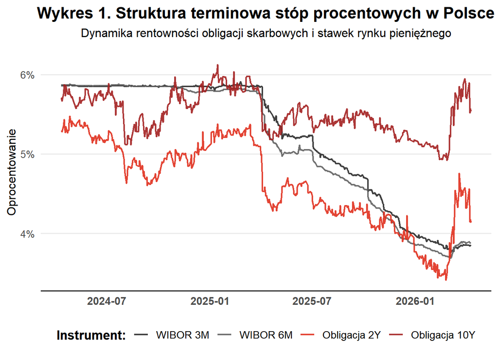

```r
df_long <- df_oprocentowanie %>%
  pivot_longer(
    cols = c(bond_10y, bond_2y, wibor_6m, wibor_3m),
    names_to = "instrument",
    values_to = "yield"
  ) %>%
  mutate(instrument = factor(instrument, levels = c("wibor_3m", "wibor_6m", "bond_2y", "bond_10y")))

pwc_colors <- c(
  "wibor_3m" = "#2b2b2b",
  "wibor_6m" = "#606060",
  "bond_2y"  = "#E0301E",
  "bond_10y" = "#A32020"
)

ggplot(df_long, aes(x = date, y = yield, color = instrument)) +
  # Rysowanie linii
  geom_line(linewidth = 0.85, alpha = 0.9) +
  scale_color_manual(
    values = pwc_colors,
    labels = c("WIBOR 3M", "WIBOR 6M", "Obligacja 2Y", "Obligacja 10Y")
  ) +
  scale_y_continuous(labels = function(x) paste0(x, "%")) +
  labs(
    title = "Wykres 1. Struktura terminowa stóp procentowych w Polsce",
    subtitle = "Dynamika rentowności obligacji skarbowych i stawek rynku pieniężnego",
    x = NULL,
    y = "Oprocentowanie",
    color = "Instrument:"
  ) +
  theme_minimal(base_size = 13) +

  theme(
    plot.title = element_text(hjust = 0.5, face = "bold", size = 16),
    plot.subtitle = element_text(hjust = 0.5, size = 12, margin = margin(b = 15)),

    legend.position = "bottom",
    legend.title = element_text(face = "bold"),

    panel.grid.minor = element_blank(),
    panel.grid.major.x = element_blank(),

    axis.text.x = element_text(size = 11, face = "bold"),
    axis.text.y = element_text(size = 10),

    axis.title = element_text(size = 12),

    axis.line.x = element_line(color = "#2b2b2b", linewidth = 0.6)
  )
```

```r
get_r_interpolated <- function(ttm_val, r3m, r6m, r2y, r10y) {
  x_nodes <- c(0.25, 0.5, 2.0, 10.0)
  y_nodes <- c(r3m, r6m, r2y, r10y) / 100
  curve_func <- splinefun(x_nodes, y_nodes, method = "monoH.FC")
  return(curve_func(ttm_val))
}

call_eur <- call_eur %>%
  left_join(df_oprocentowanie, by = "date") %>%
  rowwise() %>%
  mutate(
    r_mkt = get_r_interpolated(days_to_maturity / 365, wibor_3m, wibor_6m, bond_2y, bond_10y),
    r_cont = log(1 + r_mkt)
  ) %>%
  ungroup() %>%
  select(-wibor_3m, -wibor_6m, -bond_2y, -bond_10y)

put_eur <- put_eur %>%
  left_join(df_oprocentowanie, by = "date") %>%
  rowwise() %>%
  mutate(
    r_mkt = get_r_interpolated(days_to_maturity / 365, wibor_3m, wibor_6m, bond_2y, bond_10y),
    r_cont = log(1 + r_mkt)
  ) %>%
  ungroup() %>%
  select(-wibor_3m, -wibor_6m, -bond_2y, -bond_10y)

print("Kolumna r_cont wyliczona na podstawie days_to_maturity:")
head(call_eur %>% select(date, days_to_maturity, r_mkt, r_cont))
```

[output not shown]

Na podstawie danych dziennych możliwe było skonstruowanie krzywej dochodowości dla każdej daty wyceny poprzez interpolację dostępnych punktów rynkowych. Oznacza to, że dla każdego dnia analizowanego okresu wyznaczana jest odrębna krzywa odpowiadająca aktualnym warunkom rynkowym.

Poniżej przedstawiono przykładową krzywą dochodowości dla pierwszego dnia wyceny opcji, tj. 10 listopada 2025 roku.

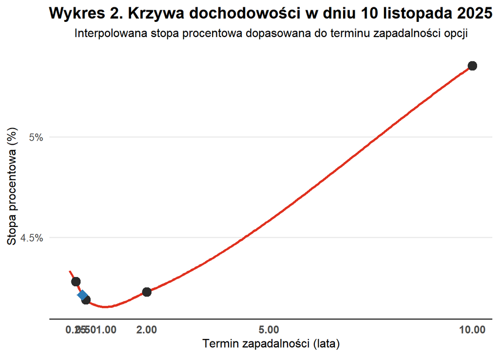

```r
current_date <- call_eur$date[1]

raw_rates <- df_oprocentowanie %>% filter(date == current_date)

nodes_x <- c(0.25, 0.5, 2.0, 10.0) # 3M, 6M, 2Y, 10Y
nodes_y <- c(raw_rates$wibor_3m, raw_rates$wibor_6m,
             raw_rates$bond_2y, raw_rates$bond_10y)

fine_x <- seq(0.1, 10, length.out = 200)
curve_func <- splinefun(nodes_x, nodes_y, method = "monoH.FC")
fine_y <- curve_func(fine_x)

df_curve_plot <- data.frame(x = fine_x, y = fine_y)
df_nodes_plot <- data.frame(x = nodes_x, y = nodes_y)

ggplot() +
  geom_line(
    data = df_curve_plot,
    aes(x = x, y = y),
    color = "#E0301E",
    linewidth = 1.2
  ) +
  geom_point(
    data = df_nodes_plot,
    aes(x = x, y = y),
    color = "#2b2b2b",
    size = 4
  ) +
  geom_point(
    aes(x = call_eur$days_to_maturity[1] / 365,
        y = call_eur$r_mkt[1] * 100),
    color = "#2c7bb6",
    size = 5,
    shape = 18
  ) +
  scale_x_continuous(
    breaks = c(0.25, 0.5, 1, 2, 5, 10)
  ) +
  scale_y_continuous(
    labels = function(x) paste0(x, "%")
  ) +
  labs(
    title = paste("Wykres 2. Krzywa dochodowości w dniu 10 listopada 2025"),
    subtitle = "Interpolowana stopa procentowa dopasowana do terminu zapadalności opcji",
    x = "Termin zapadalności (lata)",
    y = "Stopa procentowa (%)"
  ) +
  theme_minimal(base_size = 13) +
  theme(
    plot.title = element_text(
      hjust = 0.5,
      face = "bold",
      size = 16
    ),
    plot.subtitle = element_text(
      hjust = 0.5,
      size = 12,
      margin = margin(b = 15)
    ),
    panel.grid.minor = element_blank(),
    panel.grid.major.x = element_blank(),
    axis.text.x = element_text(size = 11, face = "bold"),
    axis.text.y = element_text(size = 10),
    axis.title = element_text(size = 12),
    axis.line.x = element_line(color = "#2b2b2b", linewidth = 0.6)
  )
```

Na powyższym wykresie widoczna jest nieliniowa zależność pomiędzy terminem zapadalności a poziomem stóp procentowych. Krzywa dochodowości przyjmuje kształt zbliżony do litery „U”, co oznacza, że krótkoterminowe stopy są wyższe niż stopy średnioterminowe, przy jednoczesnym wzroście rentowności dla dłuższych terminów.

**Pierwszym** czynnikiem wpływającym na taki kształt krzywej jest różnica w charakterze instrumentów. Stawki WIBOR, wykorzystywane dla krótkich terminów, zawierają komponent ryzyka kredytowego oraz płynnościowego, przez co mogą być wyższe niż rentowności obligacji skarbowych uznawanych za instrumenty bliższe stopie wolnej od ryzyka.

**Drugim** istotnym czynnikiem są oczekiwania rynkowe dotyczące przyszłego poziomu stóp procentowych. Obserwowana inwersja pomiędzy krótkim a średnim końcem krzywej może wskazywać, że rynek dyskontuje spadek stóp procentowych w horyzoncie kilku miesięcy, przy jednoczesnym utrzymaniu wyższych rentowności dla dłuższych terminów.

**Zastrzeżenia**

Przyjęta krzywa dochodowości stanowi uproszczone przybliżenie stopy wolnej od ryzyka. Wynika to z wykorzystania różnych instrumentów (WIBOR oraz obligacje), które różnią się profilem ryzyka oraz płynności.

W szczególności WIBOR zawiera komponent ryzyka kredytowego, przez co nie jest bezpośrednią miarą stopy wolnej od ryzyka.

Pomimo tych ograniczeń, przyjęte podejście jest wystarczające na potrzeby analizy porównawczej metod wyceny opcji.

# 4 Model Blacka - Scholesa

## 4.1 Istota modelu Blacka–Scholesa

Model Blacka–Scholesa jest jednym z podstawowych narzędzi wykorzystywanych do wyceny opcji europejskich. Jego głównym założeniem jest możliwość określenia „sprawiedliwej” ceny opcji na podstawie kilku kluczowych parametrów rynkowych, takich jak cena instrumentu bazowego, zmienność, stopa procentowa oraz czas do zapadalności.

Model opiera się na założeniu, że ceny aktywów finansowych zmieniają się w sposób ciągły i losowy, a rynek jest efektywny, co pozwala na eliminację możliwości arbitrażu. W praktyce oznacza to, że cena opcji wynika bezpośrednio z relacji pomiędzy aktualną ceną instrumentu bazowego a zdyskontowaną wartością ceny wykonania.

**Wzór na cenę opcji call:**

$$C(S_t, t) = N(d_1) S_t - N(d_2) K e^{-r(T - t)}$$

**Wzór na cenę opcji put:**

$$P(S_t, t) = K e^{-r(T - t)} - S_t + C(S_t, t)$$

gdzie:  
- $S_t$ – cena instrumentu bazowego w czasie $t$  
- $K$ – cena wykonania opcji (strike)  
- $r$ – stopa wolna od ryzyka  
- $T - t$ – czas do zapadalności  
- $\sigma$ – zmienność instrumentu bazowego  
- $N(d)$ – dystrybuanta standaryzowanego rozkładu normalnego  
- $d_1, d_2$ – parametry modelu

Model ten pozwala na szybkie i spójne oszacowanie wartości opcji, jednak opiera się na kilku uproszczeniach, takich jak stała zmienność czy stała stopa procentowa.

```r
df_kghm_sigma = df_kghm %>%
  arrange(date) %>%
  mutate(
    sigma_raw = slider::slide_dbl(
      log_return,
      sd,
      .before = 129,
      .complete = TRUE,
      na.rm = TRUE
    ),
    sigma = dplyr::lag(sigma_raw) * sqrt(252)
  ) %>%
  select(date, sigma)

call_eur = call_eur %>%
  left_join(df_kghm_sigma, by = "date") %>%
  filter(!is.na(sigma))

put_eur = put_eur %>%
  left_join(df_kghm_sigma, by = "date") %>%
  filter(!is.na(sigma))
```

```r
call_eur = call_eur %>%
  select(-any_of(c("tau", "d1", "d2", "bs_price", "bs_result")))

put_eur = put_eur %>%
  select(-any_of(c("tau", "d1", "d2", "bs_price", "bs_result")))


black_scholes = function(S, K, r, sigma, tau, type = "call") {

  d1 = (log(S / K) + (r + 0.5 * sigma^2) * tau) / (sigma * sqrt(tau))
  d2 = d1 - sigma * sqrt(tau)

  if (type == "call") {
    price = S * pnorm(d1) - K * exp(-r * tau) * pnorm(d2)
  } else if (type == "put") {
    price = K * exp(-r * tau) * pnorm(-d2) - S * pnorm(-d1)
  }

  tibble(
    d1 = d1,
    d2 = d2,
    bs_price = round(price, 2)   # <-- ZAOKRĄGLENIE
  )
}


call_eur = call_eur %>%
  mutate(
    tau = days_to_maturity / 365
  ) %>%
  filter(tau > 0) %>%
  rowwise() %>%
  mutate(
    bs_result = list(
      black_scholes(
        S = close,
        K = strike,
        r = r_cont,
        sigma = sigma,
        tau = tau,
        type = "call"
      )
    )
  ) %>%
  tidyr::unnest(bs_result) %>%
  ungroup()


put_eur = put_eur %>%
  mutate(
    tau = days_to_maturity / 365
  ) %>%
  filter(tau > 0) %>%
  rowwise() %>%
  mutate(
    bs_result = list(
      black_scholes(
        S = close,
        K = strike,
        r = r_cont,
        sigma = sigma,
        tau = tau,
        type = "put"
      )
    )
  ) %>%
  tidyr::unnest(bs_result) %>%
  ungroup()
```

```r
call_eur = call_eur %>%
  mutate(
    N_d1 = round(pnorm(d1), 2),
    N_d2 = round(pnorm(d2),2)
  )

put_eur = put_eur %>%
  mutate(
    N_minus_d1 = round(pnorm(-d1), 2),
    N_minus_d2 = round(pnorm(-d2), 2)
  )
```

## 4.2 Mechanizm działania modelu

Proces wyceny opcji przebiega w kilku krokach:

1. **Określenie parametrów wejściowych** – cena instrumentu bazowego, zmienność, stopa procentowa oraz czas do zapadalności ($\tau$)
2. **Obliczenie parametrów $d_1$ i $d_2$**:

$$d_1 = \frac{\ln(S/K) + (r + \frac{1}{2}\sigma^2)\tau}{\sigma
\sqrt{\tau}}, \quad
d_2 = d_1 - \sigma \sqrt{\tau}$$

3. **Wyznaczenie ceny opcji** – poprzez zdyskontowanie przyszłej wartości wypłaty
4. **Zastosowanie w czasie** – obliczenia wykonywane są dla każdej daty, co pozwala obserwować zmiany wyceny w zależności od warunków rynkowych

## 4.3 Interpretacja wyników:

Za pomocą tego algorytmu otrzymano oszacowanie w tabeli poniżej:

```r
df_option_summary = bind_rows(
  call_eur %>% mutate(option_type = "Call"),
  put_eur  %>% mutate(option_type = "Put")
) %>%
  arrange(option_type, date) %>%
  group_by(option_type) %>%
  mutate(
    day_id = row_number(),
    last_day = max(day_id)
  ) %>%
  ungroup() %>%
  filter(day_id %in% c(1, 50) | day_id == last_day) %>%
  mutate(
    N_1 = if_else(option_type == "Call", pnorm(d1), pnorm(-d1)),
    N_2 = if_else(option_type == "Call", pnorm(d2), pnorm(-d2)),

    date = format(date, "%d.%m.%Y"),
    close = round(close, 2),
    bs_price = round(bs_price, 2),
    N_1 = round(N_1, 4),
    N_2 = round(N_2, 4)
  ) %>%
  select(
    option_type,
    day_id,
    date,
    close,
    bs_price,
    N_1,
    N_2
  )

kable(
  df_option_summary,
  col.names = c(
    "Typ opcji",
    "Dzień",
    "Data",
    "Cena akcji",
    "Cena opcji",
    "N(d1) / N(-d1)",
    "N(d2) / N(-d2)"
  ),
  align = "c",
  caption = "<span style='color:black; font-weight:700;'>Tabela 1. Kluczowe parametry wyceny opcji dla wybranych dni</span>",
  escape = FALSE
) %>%
  kable_styling(
    bootstrap_options = c("condensed"),
    full_width = FALSE,
    position = "center",
    font_size = 15
  ) %>%
  row_spec(
    0,
    bold = TRUE,
    color = "white",
    background = "#d35400"
  ) %>%
  column_spec(
    1,
    bold = TRUE,
    color = "white",
    background = "#d35400"
  )
```

Tabela 1. Kluczowe parametry wyceny opcji dla wybranych dni

| Typ opcji | Dzień | Data | Cena akcji | Cena opcji | N(d1) / N(-d1) | N(d2) / N(-d2) |
| --- | --- | --- | --- | --- | --- | --- |
| Call | 1 | 10.11.2025 | 195.65 | 2.97 | 0.1554 | 0.1116 |
| Call | 50 | 27.01.2026 | 332.00 | 84.55 | 0.9710 | 0.9587 |
| Call | 100 | 09.04.2026 | 303.20 | 53.23 | 1.0000 | 1.0000 |
| Put | 1 | 10.11.2025 | 195.65 | 53.09 | 0.8446 | 0.8884 |
| Put | 50 | 27.01.2026 | 332.00 | 0.63 | 0.0290 | 0.0413 |
| Put | 100 | 09.04.2026 | 303.20 | 0.00 | 0.0000 | 0.0000 |

W tabeli zaprezentowano wybrane momenty z szeregu wyceny opcji: dzień początkowy (10.11.2025), połowę okresu (27.01.2026) oraz dzień zapadalności (09.04.2026).

**Opcja call:**

W pierwszym dniu opcja call znajdowała się głęboko poza pieniądzem (OTM), co tłumaczy jej niską wartość (2,97 PLN). Niskie prawdopodobieństwo osiągnięcia ceny wykonania (250 PLN) implikowało ograniczoną wartość oczekiwaną wypłaty.

W kolejnych dniach nastąpił istotny wzrost wartości opcji, wynikający głównie ze wzrostu ceny instrumentu bazowego. W połowie okresu opcja osiągnęła znacznie wyższą wycenę, co oznacza, że jej sprzedaż na rynku wtórnym mogła generować istotny zysk, mimo braku możliwości wcześniejszego wykonania.

W dniu zapadalności opcja pozostała in-the-money, generując dodatnią wypłatę wynikającą z różnicy pomiędzy ceną rynkową a ceną wykonania.

**Opcja put:**

Opcja put początkowo charakteryzowała się wysoką wartością, wynikającą z jej korzystnej pozycji względem ceny wykonania. Jednak wraz ze wzrostem ceny instrumentu bazowego szybko traciła na wartości.

Już w połowie okresu jej cena była bliska zeru, a w dniu zapadalności opcja wygasła bez wartości (out-of-the-money). W takim przypadku strata inwestora ogranicza się do zapłaconej premii, wynoszącej 53,09 PLN.

**Interpretacja parametrów modelu:**

Parametry $d_1$ oraz $d_2$ wynoszą odpowiednio $d_1 = -1{,}01$ oraz $d_2 = -1{,}22$ i są identyczne dla opcji call i put, ponieważ zależą wyłącznie od parametrów rynkowych. Różnice w wycenie wynikają dopiero z zastosowania funkcji dystrybuanty rozkładu normalnego w końcowych wzorach.

Ich interpretacja ekonomiczna pojawia się po przekształceniu do postaci $N(d)$. Wartość $N(d_1)$ odpowiada wrażliwości ceny opcji na zmianę ceny instrumentu bazowego (delta), natomiast $N(d_2)$ może być interpretowane jako przybliżone prawdopodobieństwo zakończenia opcji w stanie in-the-money.

W analizowanym przypadku niskie wartości $N(d_1)$ i $N(d_2)$ wskazują na ograniczoną wrażliwość opcji oraz niewielkie prawdopodobieństwo realizacji dodatniej wypłaty.

Należy podkreślić, że opcje mogą być przedmiotem obrotu na rynku wtórnym w dowolnym momencie przed terminem zapadalności. W związku z tym, oprócz wartości w dniu wykonania, istotna jest również ich bieżąca wycena w trakcie trwania kontraktu.

Z tego względu poniżej przedstawiono wykres liniowy obrazujący dzienne zmiany cen opcji.

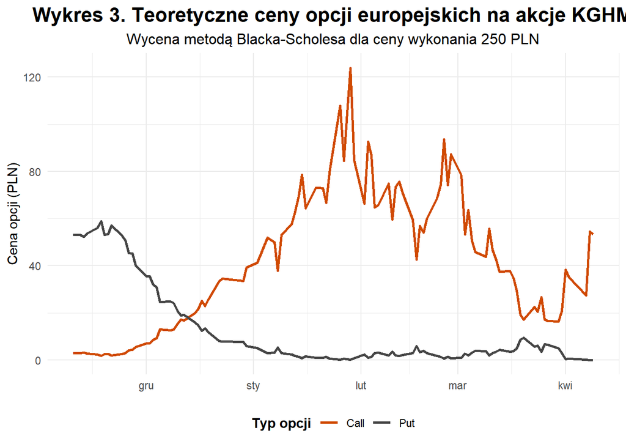

```r
option_colors = c(
  "European call" = "#D04A02",
  "European put"  = "#464646"
)

df_options_plot = bind_rows(call_eur, put_eur) %>%
  dplyr::select(date, option_type, bs_price)

ggplot(df_options_plot, aes(x = date, y = bs_price, color = option_type)) +
  geom_line(linewidth = 0.9) +

  scale_color_manual(
    values = option_colors,
    labels = c("European call" = "Call", "European put" = "Put")
  ) +

  theme_minimal() +

  labs(
    title = "Wykres 3. Teoretyczne ceny opcji europejskich na akcje KGHM",
    subtitle = "Wycena metodą Blacka-Scholesa dla ceny wykonania 250 PLN",
    x = NULL,
    y = "Cena opcji (PLN)",
    color = "Typ opcji"
  ) +

  theme(
    plot.title = element_text(hjust = 0.5, face = "bold", size = 16),
    plot.subtitle = element_text(hjust = 0.5, size = 12),
    legend.position = "bottom",
    legend.title = element_text(face = "bold")
  )
```

Na wykresie przedstawiono zmiany wartości opcji w czasie, które odzwierciedlają wpływ zmienności instrumentu bazowego oraz czasu pozostałego do zapadalności. Widoczna jest rosnąca wartość opcji call wraz ze wzrostem ceny akcji oraz stopniowy spadek wartości opcji put, co wynika z ich przeciwstawnej charakterystyki.

W celu lepszego zobrazowania zależności pomiędzy wyceną opcji a zachowaniem instrumentu bazowego, na wykresie przedstawiono również skumulowaną stopę zwrotu. Pozwala to zauważyć, że zmiany wartości opcji call są silnie powiązane z kierunkiem ruchu ceny akcji, podczas gdy opcja put zachowuje się odwrotnie.

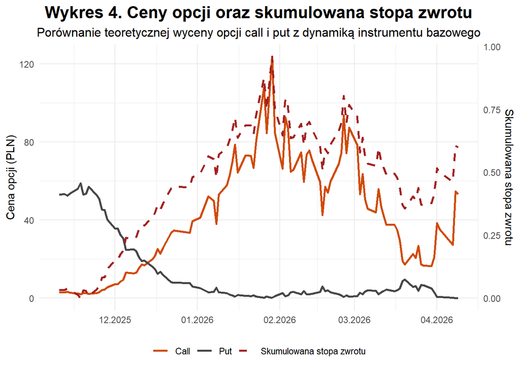

```r
option_colors = c(
  "Call" = "#D04A02",
  "Put"  = "#464646",
  "Skumulowana stopa zwrotu" = "#A32020"
)

df_options_plot = bind_rows(call_eur, put_eur) %>%
  dplyr::select(date, option_type, bs_price) %>%
  dplyr::mutate(
    option_type = dplyr::case_when(
      option_type == "European call" ~ "Call",
      option_type == "European put"  ~ "Put"
    )
  )

df_return_plot = df_kghm %>%
  dplyr::filter(date >= min(df_options_plot$date),
                date <= max(df_options_plot$date)) %>%
  dplyr::arrange(date) %>%
  dplyr::mutate(
    cumulative_return = exp(cumsum(log_return)) - 1,
    series = "Skumulowana stopa zwrotu"
  )

scale_factor = max(df_options_plot$bs_price, na.rm = TRUE) /
  max(df_return_plot$cumulative_return, na.rm = TRUE)

ggplot() +

  geom_line(
    data = df_options_plot,
    aes(x = date, y = bs_price, color = option_type),
    linewidth = 0.9
  ) +

  geom_line(
    data = df_return_plot,
    aes(x = date, y = cumulative_return * scale_factor, color = series),
    linewidth = 0.9,
    linetype = "dashed"
  ) +

  scale_color_manual(values = option_colors) +

  scale_y_continuous(
    name = "Cena opcji (PLN)",
    sec.axis = sec_axis(
      ~ . / scale_factor,
      name = "Skumulowana stopa zwrotu"
    )
  ) +

  scale_x_date(date_labels = "%m.%Y") +

  theme_minimal() +

  labs(
    title = "Wykres 4. Ceny opcji oraz skumulowana stopa zwrotu",
    subtitle = "Porównanie teoretycznej wyceny opcji call i put z dynamiką instrumentu bazowego",
    x = NULL,
    color = NULL
  ) +

  theme(
    plot.title = element_text(hjust = 0.5, face = "bold", size = 16),
    plot.subtitle = element_text(hjust = 0.5, size = 12),
    legend.position = "bottom",
    legend.title = element_text(face = "bold")
  )
```

**Podsumowanie**

Model Blacka–Scholesa umożliwia szybką i spójną wycenę opcji europejskich na podstawie kluczowych parametrów rynkowych. Jego zaletą jest prostota i przejrzystość.

Główne ograniczenia to założenie stałej zmienności oraz stopy procentowej, co odbiega od realiów rynkowych. Mimo to stanowi on podstawowy punkt odniesienia dla bardziej zaawansowanych metod wyceny.

# 5 Metoda Monte Carlo

## 5.1 Istota metody Monte Carlo

Metoda Monte Carlo jest inną techniką wyceny opcji opartą na symulacji losowych ścieżek przyszłych cen instrumentu bazowego. Zamiast korzystać z jednego wzoru, model generuje wiele możliwych scenariuszy zachowania ceny w czasie, a następnie na ich podstawie oblicza średnią wartość wypłaty opcji.

W praktyce oznacza to, że cena opcji jest interpretowana jako zdyskontowana wartość oczekiwana jej przyszłej wypłaty, wyznaczona na podstawie dużej liczby symulacji.

Podejście to pozwala na większą elastyczność niż model Blacka–Scholesa, ponieważ może uwzględniać bardziej złożone założenia dotyczące rynku.

## 5.2 Mechanizm działania metody

Proces wyceny metodą Monte Carlo polega na symulacji wielu możliwych ścieżek przyszłej ceny instrumentu bazowego, a następnie obliczeniu wypłaty opcji dla każdej z nich.

W pierwszym kroku generowane są losowe scenariusze zmian ceny w czasie, przy założeniu określonej zmienności i stopy procentowej. Następnie dla każdej ścieżki wyznaczana jest wartość opcji w dniu zapadalności.

W kolejnym etapie obliczana jest średnia z uzyskanych wypłat, która po zdyskontowaniu stanowi przybliżoną cenę opcji.

W analizie zastosowano dwie liczby symulacji – 10 000 oraz 50 000 ścieżek – co pozwala na ocenę wpływu liczby scenariuszy na stabilność i dokładność wyceny.

```r
monte_carlo_option = function(S, K, r, sigma, tau, type = "call", n_scenarios = 10000) {

  z = rnorm(n_scenarios)

  S_T = S * exp((r - 0.5 * sigma^2) * tau + sigma * sqrt(tau) * z)

  if (type == "call") {
    payoff = pmax(S_T - K, 0)
  } else {
    payoff = pmax(K - S_T, 0)
  }

  price = exp(-r * tau) * mean(payoff)

  return(price)
}
```

```r
set.seed(123)

call_eur = call_eur %>%
  rowwise() %>%
  mutate(
    mc_10000 = monte_carlo_option(close, strike, r_cont, sigma, tau, "call", 10000),
    mc_50000 = monte_carlo_option(close, strike, r_cont, sigma, tau, "call", 50000)
  ) %>%
  ungroup() %>%
  mutate(
    mc_10000 = round(mc_10000, 2),
    mc_50000 = round(mc_50000, 2)
  )
```

```r
set.seed(123)

put_eur = put_eur %>%
  rowwise() %>%
  mutate(
    mc_10000 = monte_carlo_option(close, strike, r_cont, sigma, tau, "put", 10000),
    mc_50000 = monte_carlo_option(close, strike, r_cont, sigma, tau, "put", 50000)
  ) %>%
  ungroup() %>%
  mutate(
    mc_10000 = round(mc_10000, 2),
    mc_50000 = round(mc_50000, 2)
  )
```

## 5.3 Porównanie ilości ścieżek (50 tys. vs 10 tys.)

Na początku interpretacji wyników porównano różnice w wycenie wynikające z zastosowania różnej liczby ścieżek symulacyjnych (10 000 vs 50 000).

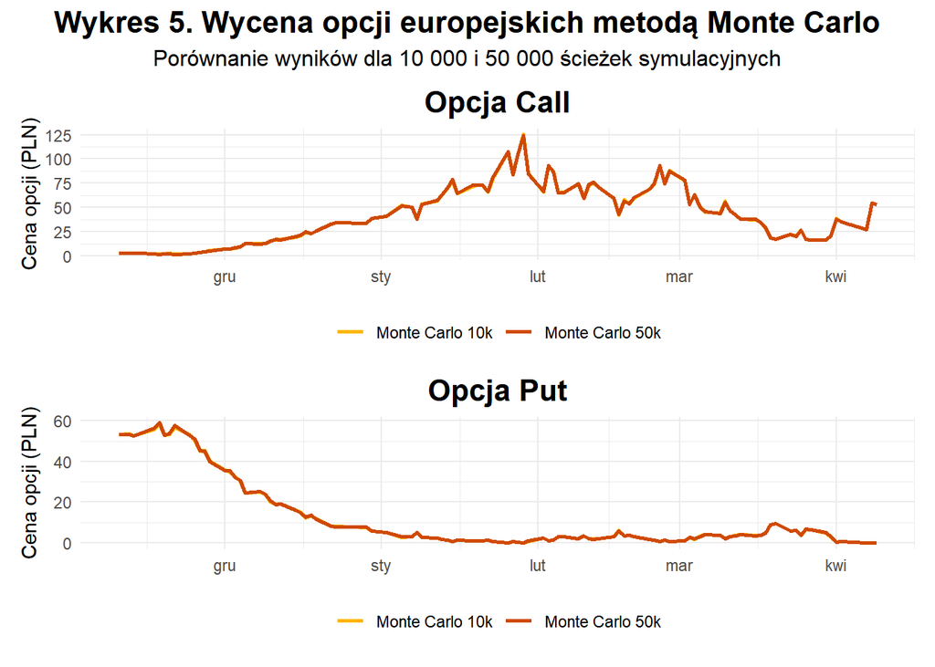

```r
mc_colors = c(
  "Monte Carlo 10k" = "#FFB600",
  "Monte Carlo 50k" = "#D04A02"
)

p_call = call_eur %>%
  select(date, mc_10000, mc_50000) %>%
  pivot_longer(
    cols = c(mc_10000, mc_50000),
    names_to = "method",
    values_to = "price"
  ) %>%
  mutate(
    method = case_when(
      method == "mc_10000" ~ "Monte Carlo 10k",
      method == "mc_50000" ~ "Monte Carlo 50k"
    )
  ) %>%
  ggplot(aes(x = date, y = price, color = method)) +
  geom_line(linewidth = 0.9) +

  scale_color_manual(values = mc_colors) +

  theme_minimal() +

  labs(
    title = "Opcja Call",
    x = NULL,
    y = "Cena opcji (PLN)",
    color = NULL
  ) +

  theme(
    plot.title = element_text(face = "bold", size = 13),
    legend.position = "bottom"
  )

p_put = put_eur %>%
  select(date, mc_10000, mc_50000) %>%
  pivot_longer(
    cols = c(mc_10000, mc_50000),
    names_to = "method",
    values_to = "price"
  ) %>%
  mutate(
    method = case_when(
      method == "mc_10000" ~ "Monte Carlo 10k",
      method == "mc_50000" ~ "Monte Carlo 50k"
    )
  ) %>%
  ggplot(aes(x = date, y = price, color = method)) +
  geom_line(linewidth = 0.9) +

  scale_color_manual(values = mc_colors) +

  theme_minimal() +

  labs(
    title = "Opcja Put",
    x = NULL,
    y = "Cena opcji (PLN)",
    color = NULL
  ) +

  theme(
    plot.title = element_text(face = "bold", size = 13),
    legend.position = "bottom"
  )

(p_call / p_put) +
  plot_annotation(
    title = "Wykres 5. Wycena opcji europejskich metodą Monte Carlo",
    subtitle = "Porównanie wyników dla 10 000 i 50 000 ścieżek symulacyjnych"
  ) &
  theme(
    plot.title = element_text(hjust = 0.5, face = "bold", size = 16),
    plot.subtitle = element_text(hjust = 0.5, size = 12)
  )
```

Jak widać na wykresie, różnice pomiędzy wycenami uzyskanymi dla 10 000 oraz 50 000 ścieżek są na tyle niewielkie, że pozostają praktycznie niewidoczne. Linie nachodzą na siebie, co wskazuje na wysoką zbieżność wyników.

W celu dokładniejszej analizy przygotowano wykres przedstawiający bezwzględne różnice pomiędzy wycenami uzyskanymi przy zastosowaniu obu wariantów symulacji.

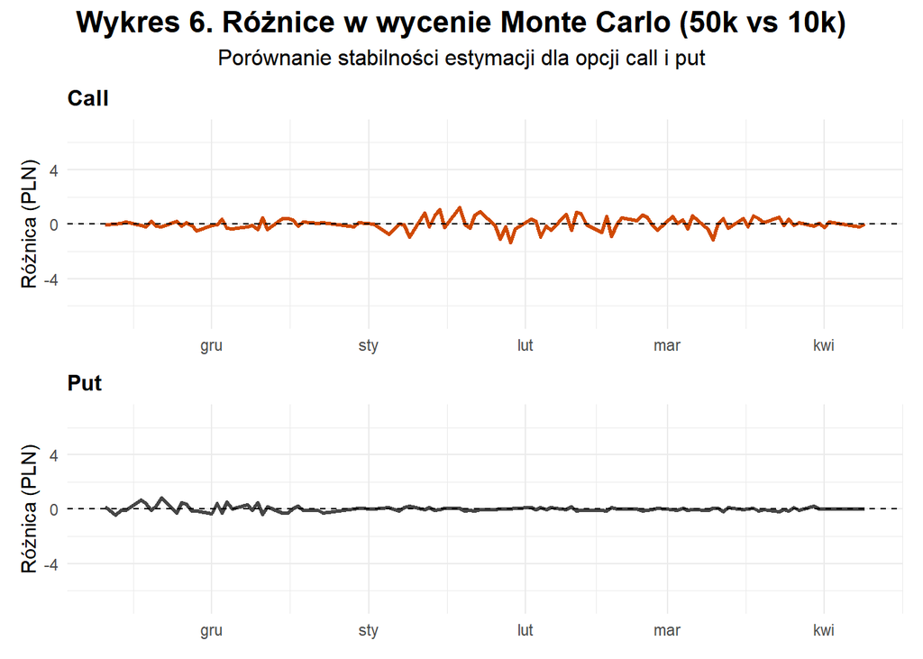

```r
diff_colors = c(
  "Call" = "#D04A02",
  "Put"  = "#464646"
)

p_call_diff = call_eur %>%
  mutate(diff = mc_50000 - mc_10000,
         option_type = "Call") %>%
  ggplot(aes(x = date, y = diff, color = option_type)) +
  geom_line(linewidth = 0.9) +
  geom_hline(yintercept = 0, linetype = "dashed") +
  coord_cartesian(ylim = c(-7, 7)) +
  scale_color_manual(values = diff_colors) +
  theme_minimal() +
  labs(
    title = "Call",
    x = NULL,
    y = "Różnica (PLN)",
    color = NULL
  ) +
  theme(
    plot.title = element_text(face = "bold", size = 12),
    legend.position = "none"
  )

p_put_diff = put_eur %>%
  mutate(diff = mc_50000 - mc_10000,
         option_type = "Put") %>%
  ggplot(aes(x = date, y = diff, color = option_type)) +
  geom_line(linewidth = 0.9) +
  geom_hline(yintercept = 0, linetype = "dashed") +
  coord_cartesian(ylim = c(-7, 7)) +
  scale_color_manual(values = diff_colors) +
  theme_minimal() +
  labs(
    title = "Put",
    x = NULL,
    y = "Różnica (PLN)",
    color = NULL
  ) +
  theme(
    plot.title = element_text(face = "bold", size = 12),
    legend.position = "none"
  )

(p_call_diff / p_put_diff) +
  plot_annotation(
    title = "Wykres 6. Różnice w wycenie Monte Carlo (50k vs 10k)",
    subtitle = "Porównanie stabilności estymacji dla opcji call i put",
    theme = theme(
      plot.title = element_text(hjust = 0.5, face = "bold", size = 16),
      plot.subtitle = element_text(hjust = 0.5, size = 12)
    )
  )
```

Na wykresie widać, że różnice pomiędzy wycenami są niewielkie i oscylują wokół zera, co potwierdza stabilność wyników uzyskanych metodą Monte Carlo.

Należy jednak podkreślić, że nawet niewielkie odchylenia w wycenie mogą mieć istotne znaczenie przy większej skali inwestycji.

# 6 Black Scholes vs Monte Carlo

## 6.1 Interpretacja wyników

```r
df_bs_mc_summary = bind_rows(
  call_eur %>% mutate(option_type = "Call"),
  put_eur  %>% mutate(option_type = "Put")
) %>%
  arrange(option_type, date) %>%
  group_by(option_type) %>%
  mutate(day_id = row_number()) %>%
  ungroup() %>%
  filter(day_id %in% c(1, 50)) %>%
  mutate(
    date = format(date, "%d.%m.%Y"),
    bs_price = round(bs_price, 2),
    mc_10000 = round(mc_10000, 2),
    mc_50000 = round(mc_50000, 2)
  ) %>%
  select(
    option_type,
    day_id,
    date,
    bs_price,
    mc_10000,
    mc_50000
  )

kable(
  df_bs_mc_summary,
  col.names = c(
    "Typ opcji",
    "Dzień",
    "Data",
    "Black-Scholes",
    "Monte Carlo 10k",
    "Monte Carlo 50k"
  ),
  align = "c",
  caption = "<span style='color:black; font-weight:700;'>Tabela 2. Porównanie wyceny Blacka-Scholesa i Monte Carlo dla wybranych dni</span>",
  escape = FALSE
) %>%
  kable_styling(
    bootstrap_options = c("condensed"),
    full_width = FALSE,
    position = "center",
    font_size = 15
  ) %>%
  row_spec(
    0,
    bold = TRUE,
    color = "white",
    background = "#d35400"
  ) %>%
  column_spec(
    1,
    bold = TRUE,
    color = "white",
    background = "#d35400"
  )
```

Tabela 2. Porównanie wyceny Blacka-Scholesa i Monte Carlo dla wybranych dni

| Typ opcji | Dzień | Data | Black-Scholes | Monte Carlo 10k | Monte Carlo 50k |
| --- | --- | --- | --- | --- | --- |
| Call | 1 | 10.11.2025 | 2.97 | 2.94 | 2.89 |
| Call | 50 | 27.01.2026 | 84.55 | 85.07 | 83.99 |
| Put | 1 | 10.11.2025 | 53.09 | 53.17 | 53.36 |
| Put | 50 | 27.01.2026 | 0.63 | 0.63 | 0.64 |

**Kluczowe obserwacje:**

**Dzień początkowy (dzień 1):**  
Różnice pomiędzy metodami są minimalne dla obu typów opcji (call i put), co potwierdza spójność wyników oraz poprawność implementacji symulacji Monte Carlo.

**Połowa okresu (dzień 50):**  
Odchylenia stają się bardziej widoczne, szczególnie dla opcji call, jednak nadal pozostają relatywnie niewielkie względem poziomu wyceny. Wynika to z rosnącej wrażliwości opcji na zmiany parametrów rynkowych oraz losowego charakteru symulacji.

**Opcja put:**  
Ze względu na bardzo niską wartość opcji, nawet niewielkie różnice bezwzględne przekładają się na istotne odchylenia względne, co jest naturalne dla instrumentów bliskich zerowej wycenie.

```r
df_diff_summary = bind_rows(
  call_eur %>% mutate(option_type = "Call"),
  put_eur  %>% mutate(option_type = "Put")
) %>%
  arrange(option_type, date) %>%
  group_by(option_type) %>%
  mutate(day_id = row_number()) %>%
  ungroup() %>%
  filter(day_id %in% c(1, 50)) %>%
  mutate(
    abs_diff_10k = abs(mc_10000 - bs_price),
    abs_diff_50k = abs(mc_50000 - bs_price),

    rel_diff_10k = abs_diff_10k / bs_price,
    rel_diff_50k = abs_diff_50k / bs_price,

    date = format(date, "%d.%m.%Y"),

    abs_diff_10k = round(abs_diff_10k, 2),
    abs_diff_50k = round(abs_diff_50k, 2),

    rel_diff_10k = percent(rel_diff_10k, accuracy = 0.01),
    rel_diff_50k = percent(rel_diff_50k, accuracy = 0.01)
  ) %>%
  select(
    option_type,
    day_id,
    date,
    abs_diff_10k,
    abs_diff_50k,
    rel_diff_10k,
    rel_diff_50k
  )

kable(
  df_diff_summary,
  col.names = c(
    "Typ opcji",
    "Dzień",
    "Data",
    "Różnica abs (10k)",
    "Różnica abs (50k)",
    "Różnica % (10k)",
    "Różnica % (50k)"
  ),
  align = "c",
  caption = "<span style='color:black; font-weight:700;'>Tabela 3. Różnice absolutne i względne między Black-Scholes a Monte Carlo</span>",
  escape = FALSE
) %>%
  kable_styling(
    bootstrap_options = c("condensed"),
    full_width = FALSE,
    position = "center",
    font_size = 15
  ) %>%
  row_spec(
    0,
    bold = TRUE,
    color = "white",
    background = "#d35400"
  ) %>%
  column_spec(
    1,
    bold = TRUE,
    color = "white",
    background = "#d35400"
  )
```

Tabela 3. Różnice absolutne i względne między Black-Scholes a Monte Carlo

| Typ opcji | Dzień | Data | Różnica abs (10k) | Różnica abs (50k) | Różnica % (10k) | Różnica % (50k) |
| --- | --- | --- | --- | --- | --- | --- |
| Call | 1 | 10.11.2025 | 0.03 | 0.08 | 1.01% | 2.69% |
| Call | 50 | 27.01.2026 | 0.52 | 0.56 | 0.62% | 0.66% |
| Put | 1 | 10.11.2025 | 0.08 | 0.27 | 0.15% | 0.51% |
| Put | 50 | 27.01.2026 | 0.00 | 0.01 | 0.00% | 1.59% |

**Kluczowe obserwacje:**

## 6.2 Praktyczny przykład ilustrujący różnice

W celu zobrazowania praktycznego znaczenia obserwowanych odchyleń pomiędzy metodami, przeprowadzono symulację inwestycji o wartości 100 000 PLN w opcję call.

Opcja put nie została uwzględniona w tabeli, ponieważ w analizowanym scenariuszu wygasa bez wartości (out-of-the-money). W przeciwieństwie do kontraktów terminowych, opcje nie generują nieograniczonej straty – maksymalna strata inwestora ogranicza się do zapłaconej ceny opcji.

W praktyce oznacza to, że w przypadku inwestycji w opcję put strata wyniosłaby około 100 000 PLN, czyli całość zainwestowanego kapitału.

```r
S_T = tail(df_kghm$close, 1)

df_call_day1 = call_eur %>%
  arrange(date) %>%
  slice(1)


budget = 100000

df_investment_call = tibble(
  method = c("Black-Scholes", "Monte Carlo 10k", "Monte Carlo 50k"),
  option_price = c(
    df_call_day1$bs_price,
    df_call_day1$mc_10000,
    df_call_day1$mc_50000
  )
) %>%
  mutate(
    n_options = floor(budget / option_price),

    payoff_total = n_options * pmax(S_T - df_call_day1$strike, 0),

    cost_total = n_options * option_price,

    total_profit = payoff_total - cost_total
  ) %>%
  mutate(
    option_price = format(round(option_price, 2), decimal.mark = ","),
    n_options = format(round(n_options, 0), big.mark = " "),
    total_profit = paste0(
      format(round(total_profit, 0), big.mark = " ", decimal.mark = ","),
      " zł"
    )
  ) %>%
  select(
    method,
    option_price,
    n_options,
    total_profit
  )

kable(
  df_investment_call,
  col.names = c(
    "Metoda",
    "Cena opcji",
    "Liczba opcji",
    "Zysk/Strata (netto)"
  ),
  align = "c",
  caption = "<span style='color:black; font-weight:700;'>Tabela 4. Wynik netto inwestycji 100 000 zł w opcję call</span>",
  escape = FALSE
) %>%
  kable_styling(
    bootstrap_options = c("condensed"),
    full_width = FALSE,
    position = "center",
    font_size = 15
  ) %>%
  row_spec(
    0,
    bold = TRUE,
    color = "white",
    background = "#d35400"
  ) %>%
  column_spec(
    1,
    bold = TRUE,
    color = "white",
    background = "#d35400"
  )
```

Tabela 4. Wynik netto inwestycji 100 000 zł w opcję call

| Metoda | Cena opcji | Liczba opcji | Zysk/Strata (netto) |
| --- | --- | --- | --- |
| Black-Scholes | 2,97 | 33 670 | 2 027 944 zł |
| Monte Carlo 10k | 2,94 | 34 013 | 2 049 623 zł |
| Monte Carlo 50k | 2,89 | 34 602 | 2 086 847 zł |

**Interpretacja wyników**

W analizowanym scenariuszu widoczny jest efekt wysokiej dźwigni finansowej charakterystycznej dla opcji. Wynika on z relatywnie niskiej ceny pojedynczej opcji przy jednocześnie dużym potencjale wypłaty, co pozwala na uzyskanie istotnej ekspozycji rynkowej przy ograniczonym kapitale.

W konsekwencji nawet niewielkie różnice w wycenie jednostkowej przekładają się na znaczące różnice w wyniku inwestycyjnym. W analizie różnica pomiędzy wyceną metodą Blacka–Scholesa a Monte Carlo prowadzi do rozbieżności wyniku na poziomie około 60 000 PLN, co stanowi istotną część początkowego kapitału.

Należy jednak podkreślić, że obserwowany efekt jest bezpośrednio związany z wysoką dźwignią – w takich warunkach nawet niewielkie odchylenia modelowe mogą mieć istotne znaczenie dla końcowego wyniku.

**Wniosek:**  
W przypadku opcji o wysokim ryzyku (głęboko OTM) nawet niewielkie różnice w wycenie mogą prowadzić do znaczących rozbieżności w wynikach inwestycyjnych.

## 6.3 Greki

W celu pogłębienia analizy wyceny opcji przedstawiono wartości tzw. „Grek”, czyli miar wrażliwości ceny opcji na zmiany kluczowych parametrów rynkowych.

W analizie uwzględniono następujące miary:

**Delta** – określa wrażliwość ceny opcji na zmianę ceny instrumentu bazowego  
**Vega** – mierzy wpływ zmiany zmienności na wartość opcji  
**Theta (dzienna)** – pokazuje, jak zmienia się wartość opcji wraz z upływem czasu (spadek wartości w ujęciu dziennym)

Greki stanowią istotne uzupełnienie analizy, pozwalając lepiej zrozumieć źródła zmian wartości opcji.

```r
fix_sigma = function(df) {

  sigma_cols = intersect(c("sigma", "sigma.y", "sigma.x"), names(df))

  df %>%
    mutate(
      sigma = coalesce(!!!syms(sigma_cols))
    ) %>%
    select(-any_of(c("sigma.x", "sigma.y")))
}

call_eur = fix_sigma(call_eur)
put_eur = fix_sigma(put_eur)


call_eur = call_eur %>%
  mutate(
    delta = pnorm(d1),
    vega = close * dnorm(d1) * sqrt(tau) / 100,
    theta = (
      -(close * dnorm(d1) * sigma) / (2 * sqrt(tau)) -
        r_cont * strike * exp(-r_cont * tau) * pnorm(d2)
    ) / 365
  )

put_eur = put_eur %>%
  mutate(
    delta = pnorm(d1) - 1,
    vega = close * dnorm(d1) * sqrt(tau) / 100,
    theta = (
      -(close * dnorm(d1) * sigma) / (2 * sqrt(tau)) +
        r_cont * strike * exp(-r_cont * tau) * pnorm(-d2)
    ) / 365
  )


df_greeks_summary = bind_rows(
  call_eur %>% mutate(option_type = "Call"),
  put_eur  %>% mutate(option_type = "Put")
) %>%
  arrange(option_type, date) %>%
  group_by(option_type) %>%
  mutate(
    day_id = row_number(),
    last_day = max(day_id)
  ) %>%
  ungroup() %>%
  filter(day_id %in% c(1, 50) | day_id == last_day) %>%
  mutate(
    date = format(date, "%d.%m.%Y"),
    delta = round(delta, 4),
    vega = round(vega, 4),
    theta = round(theta, 4)
  ) %>%
  select(
    option_type,
    day_id,
    date,
    delta,
    vega,
    theta
  )


kable(
  df_greeks_summary,
  col.names = c(
    "Typ opcji",
    "Dzień",
    "Data",
    "Delta",
    "Vega",
    "Theta dzienna"
  ),
  align = "c",
  caption = "<span style='color:black; font-weight:700;'>Tabela 5. Wartości Greeks dla modelu Blacka-Scholesa</span>",
  escape = FALSE
) %>%
  kable_styling(
    bootstrap_options = c("condensed"),
    full_width = FALSE,
    position = "center",
    font_size = 15
  ) %>%
  row_spec(
    0,
    bold = TRUE,
    color = "white",
    background = "#d35400"
  ) %>%
  column_spec(
    1,
    bold = TRUE,
    color = "white",
    background = "#d35400"
  )
```

Tabela 5. Wartości Greeks dla modelu Blacka-Scholesa

| Typ opcji | Dzień | Data | Delta | Vega | Theta dzienna |
| --- | --- | --- | --- | --- | --- |
| Call | 1 | 10.11.2025 | 0.1554 | 0.3004 | -0.0347 |
| Call | 50 | 27.01.2026 | 0.9710 | 0.0981 | -0.0492 |
| Call | 100 | 09.04.2026 | 1.0000 | 0.0000 | -0.0257 |
| Put | 1 | 10.11.2025 | -0.8446 | 0.3004 | -0.0069 |
| Put | 50 | 27.01.2026 | -0.0290 | 0.0981 | -0.0230 |
| Put | 100 | 09.04.2026 | 0.0000 | 0.0000 | 0.0000 |

**Interpretacja wyników:**

**Delta:**  
- Dla opcji call delta rośnie od 0,16 do 1,00, co oznacza przejście z pozycji OTM do głęboko ITM  
- Dla opcji put obserwujemy odwrotną zależność – delta zbliża się do 0 wraz ze spadkiem znaczenia opcji  
- Potwierdza to silne uzależnienie delty od relacji ceny instrumentu bazowego do ceny wykonania

**Vega:**  
- Najwyższa na początku okresu, następnie systematycznie maleje  
- Wraz ze zbliżaniem się do zapadalności wpływ zmienności zanika  
- W dniu zapadalności vega = 0, co oznacza brak wpływu niepewności na wycenę

**Theta (dzienna):**  
- Dla opcji call pozostaje ujemna, jednak jej przebieg nie jest liniowy  
- W połowie okresu obserwowany jest wzrost bezwzględnej wartości Thety (silniejszy time decay), co jest typowe dla opcji w pobliżu ITM  
- W końcowej fazie Theta maleje, ponieważ opcja traci wartość czasową i składa się niemal wyłącznie z wartości wewnętrznej  
- Dla opcji put Theta zbiega do zera wraz z utratą wartości rynkowej

Na wykresie widoczna jest zmiana delty opcji w czasie.

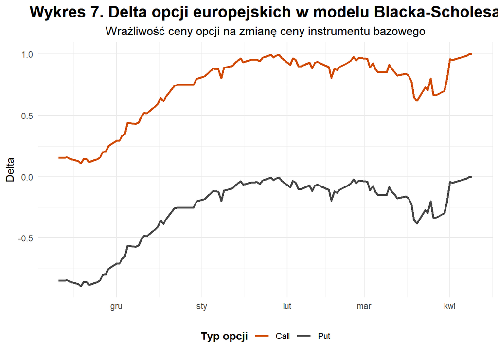

```r
df_delta_plot = bind_rows(
  call_eur %>% mutate(option_type = "Call"),
  put_eur  %>% mutate(option_type = "Put")
) %>%
  select(date, option_type, delta)

delta_colors = c(
  "Call" = "#D04A02",
  "Put"  = "#464646"
)

ggplot(df_delta_plot, aes(x = date, y = delta, color = option_type)) +
  geom_line(linewidth = 0.9) +

  scale_color_manual(values = delta_colors) +

  theme_minimal() +

  labs(
    title = "Wykres 7. Delta opcji europejskich w modelu Blacka-Scholesa",
    subtitle = "Wrażliwość ceny opcji na zmianę ceny instrumentu bazowego",
    x = NULL,
    y = "Delta",
    color = "Typ opcji"
  ) +

  theme(
    plot.title = element_text(hjust = 0.5, face = "bold", size = 16),
    plot.subtitle = element_text(hjust = 0.5, size = 12),
    legend.position = "bottom",
    legend.title = element_text(face = "bold")
  )
```

Delta opcji call rośnie z niskich wartości do poziomu bliskiego 1, co oznacza przejście z pozycji OTM do głęboko ITM i coraz silniejsze powiązanie z ceną akcji.

Dla opcji put obserwujemy odwrotny efekt – delta zbliża się do 0, co wskazuje na utratę znaczenia opcji wraz ze wzrostem ceny instrumentu bazowego.

# 7 Model Hestona

## 7.1 Istota modelu Hestona

Model Hestona stanowi rozszerzenie klasycznych podejść do wyceny opcji, eliminując jedno z ich kluczowych ograniczeń – założenie stałej zmienności. W praktyce rynkowej zmienność jest zmienna w czasie, co zostało potwierdzone w poprzednich analizach.

W szczególności dla spółek takich jak KGHM, silnie uzależnionych od czynników makroekonomicznych i geopolitycznych, zmienność ma charakter dynamiczny, co uzasadnia zastosowanie bardziej zaawansowanego modelu.

Model Hestona zakłada, że zarówno cena instrumentu bazowego, jak i jego zmienność są procesami losowymi. Kluczowym elementem jest założenie tzw. mean reversion, czyli tendencji zmienności do powrotu do długoterminowej średniej.

## 7.2 Budowa modelu Hestona

Model opiera się na kilku kluczowych elementach:

**Podwójna losowość** – zarówno cena instrumentu bazowego, jak i jego zmienność mają charakter losowy. W przeciwieństwie do modelu Blacka–Scholesa, ryzyko modelowane jest dwuwymiarowo – obejmuje nie tylko kierunek ruchu ceny, ale również dynamikę samej zmienności.

**Mean reversion** – zmienność wykazuje tendencję do powrotu do poziomu długoterminowego, a siłę tego procesu określa parametr $\kappa$. W analizie przyjęto umiarkowaną wartość $\kappa = 2{,}0$, co implikuje relatywnie szybkie wygaszanie szoków zmienności i powrót do historycznej średniej.

**Korelacja ($\rho$)** – parametr ten opisuje zależność pomiędzy zmianami ceny a zmiennością (tzw. efekt dźwigni). Przyjęto $\rho = -0{,}5$, co odzwierciedla typową dla rynków akcyjnych asymetrię: spadkom cen towarzyszy wzrost niepewności i zmienności.

**Zmienność zmienności ($\xi$)** – określa skalę wahań samej zmienności. Przyjęcie $\xi = 0{,}5$ pozwala uchwycić zjawisko „grubych ogonów”, czyli zwiększone prawdopodobieństwo ekstremalnych ruchów cenowych – istotne szczególnie dla spółek o wysokiej zmienności, takich jak KGHM.

**Symulacyjny charakter modelu** – wycena opcji opiera się na symulacji wielu scenariuszy (Monte Carlo), a następnie na obliczeniu średniej zdyskontowanej wypłaty. Podejście to zapewnia wysoką elastyczność i pozwala modelować nieliniowe profile wypłat.

**Zastrzeżenie metodologiczne (kalibracja modelu)**

W praktyce rynkowej parametry modelu Hestona ($\kappa, \rho, \xi$) są kalibrowane numerycznie tak, aby jak najlepiej odwzorować obserwowane ceny opcji (dopasowanie do tzw. *implied volatility surface*).

Ze względu na ograniczoną dostępność danych dla rynku opcji na akcje KGHM, w niniejszej analizie parametry zostały dobrane w sposób ekspercki, z zachowaniem ich interpretacji ekonomicznej.

```r
df_kghm_heston_params = df_kghm %>%
  arrange(date) %>%
  mutate(
    sigma_raw = slider::slide_dbl(
      log_return,
      sd,
      .before = 129,
      .complete = TRUE,
      na.rm = TRUE
    ),

    sigma_heston = dplyr::lag(sigma_raw) * sqrt(252),

    variance_annual_raw = (sigma_raw * sqrt(252))^2,

    theta_v_raw = slider::slide_dbl(
      variance_annual_raw,
      median,
      .before = 129,
      .complete = TRUE,
      na.rm = TRUE
    ),

    theta_v = dplyr::lag(theta_v_raw)
  ) %>%
  select(date, sigma_heston, theta_v)

call_eur = call_eur %>%
  select(-any_of(c("sigma_heston", "theta_v", "heston_price", "heston_se", "heston_result"))) %>%
  left_join(df_kghm_heston_params, by = "date") %>%
  filter(!is.na(sigma_heston), !is.na(theta_v))

put_eur = put_eur %>%
  select(-any_of(c("sigma_heston", "theta_v", "heston_price", "heston_se", "heston_result"))) %>%
  left_join(df_kghm_heston_params, by = "date") %>%
  filter(!is.na(sigma_heston), !is.na(theta_v))
```

```r
heston_mc_option = function(S, K, r, tau, v0, kappa, theta_v, xi, rho,
                            type = "call", n_scenarios = 50000) {

  n_steps = max(1, ceiling(tau * 252))
  dt = tau / n_steps

  S_path = rep(S, n_scenarios)
  v_path = rep(v0, n_scenarios)

  for (i in 1:n_steps) {

    z1 = rnorm(n_scenarios)
    z2 = rnorm(n_scenarios)

    z_v = rho * z1 + sqrt(1 - rho^2) * z2

    v_current = pmax(v_path, 0)

    S_path = S_path * exp(
      (r - 0.5 * v_current) * dt +
        sqrt(v_current * dt) * z1
    )

    v_path = v_path +
      kappa * (theta_v - v_current) * dt +
      xi * sqrt(v_current * dt) * z_v

    v_path = pmax(v_path, 0)
  }

  if (type == "call") {
    payoff = pmax(S_path - K, 0)
  } else {
    payoff = pmax(K - S_path, 0)
  }

  discounted_payoff = exp(-r * tau) * payoff

  tibble(
    heston_price = mean(discounted_payoff),
    heston_se = sd(discounted_payoff) / sqrt(n_scenarios)
  )
}
```

```r
kappa = 2.0
xi = 0.5
rho = -0.5
```

```r
set.seed(123)

call_eur = call_eur %>%
  select(-any_of(c("heston_price", "heston_se"))) %>%
  rowwise() %>%
  mutate(
    heston_result = list(
      heston_mc_option(
        S = close,
        K = strike,
        r = r_cont,
        tau = tau,
        v0 = sigma_heston^2,
        kappa = kappa,
        theta_v = theta_v,
        xi = xi,
        rho = rho,
        type = "call",
        n_scenarios = 50000
      )
    )
  ) %>%
  tidyr::unnest(heston_result) %>%
  ungroup() %>%
  mutate(
    heston_price = round(heston_price, 2),
    heston_se = round(heston_se, 4)
  )

set.seed(123)

put_eur = put_eur %>%
  select(-any_of(c("heston_price", "heston_se"))) %>%
  rowwise() %>%
  mutate(
    heston_result = list(
      heston_mc_option(
        S = close,
        K = strike,
        r = r_cont,
        tau = tau,
        v0 = sigma_heston^2,
        kappa = kappa,
        theta_v = theta_v,
        xi = xi,
        rho = rho,
        type = "put",
        n_scenarios = 50000
      )
    )
  ) %>%
  tidyr::unnest(heston_result) %>%
  ungroup() %>%
  mutate(
    heston_price = round(heston_price, 2),
    heston_se = round(heston_se, 4)
  )
```

```r
df_heston_summary = bind_rows(
  call_eur %>% mutate(option_type = "Call"),
  put_eur  %>% mutate(option_type = "Put")
) %>%
  arrange(option_type, date) %>%
  group_by(option_type) %>%
  mutate(day_id = row_number()) %>%
  ungroup() %>%
  filter(day_id %in% c(1, 50)) %>%
  mutate(
    date = format(date, "%d.%m.%Y"),
    bs_price = round(bs_price, 2),
    mc_50000 = round(mc_50000, 2),
    heston_price = round(heston_price, 2),
    heston_se = round(heston_se, 4)
  ) %>%
  select(
    option_type,
    day_id,
    date,
    bs_price,
    mc_50000,
    heston_price,
    heston_se
  )

kable(
  df_heston_summary,
  col.names = c(
    "Typ opcji",
    "Dzień",
    "Data",
    "Black-Scholes",
    "Monte Carlo 50k",
    "Heston 50k",
    "Błąd stand. Heston"
  ),
  align = "c",
  caption = "<span style='color:black; font-weight:700;'>Tabela 6. Porównanie wyceny opcji europejskich w modelu Blacka-Scholesa, Monte Carlo i Hestona</span>",
  escape = FALSE
) %>%
  kable_styling(
    bootstrap_options = c("condensed"),
    full_width = FALSE,
    position = "center",
    font_size = 15
  ) %>%
  row_spec(
    0,
    bold = TRUE,
    color = "white",
    background = "#d35400"
  ) %>%
  column_spec(
    1,
    bold = TRUE,
    color = "white",
    background = "#d35400"
  )
```

Tabela 6. Porównanie wyceny opcji europejskich w modelu Blacka-Scholesa, Monte Carlo i Hestona

| Typ opcji | Dzień | Data | Black-Scholes | Monte Carlo 50k | Heston 50k | Błąd stand. Heston |
| --- | --- | --- | --- | --- | --- | --- |
| Call | 1 | 10.11.2025 | 2.97 | 2.89 | 2.35 | 0.0432 |
| Call | 50 | 27.01.2026 | 84.55 | 83.99 | 84.78 | 0.2218 |
| Put | 1 | 10.11.2025 | 53.09 | 53.36 | 52.37 | 0.1630 |
| Put | 50 | 27.01.2026 | 0.63 | 0.64 | 1.09 | 0.0277 |

Analiza wskazuje na istotne różnice pomiędzy modelem Blacka–Scholesa a modelem Hestona. Wprowadzenie stochastycznej zmienności nie powoduje jednak jednokierunkowych odchyleń, lecz dostosowuje wycenę do aktualnej struktury ryzyka rynkowego.

**Kluczowe obserwacje:**

1. **Efekt powrotu do średniej (Dzień 1)**  
   Model Hestona wycenia opcje niżej niż Black–Scholes, ponieważ uwzględnia powrót zmienności do długoterminowej średniej, zamiast zakładać jej stały poziom.
2. **Asymetria ryzyka i grube ogony (Put, Dzień 50)**  
   Dla opcji głęboko OTM model Hestona wskazuje wyższą wycenę, odzwierciedlając ryzyko ekstremalnych zdarzeń rynkowych, które są niedoszacowane w modelu Blacka–Scholesa.
3. **Dominacja wartości wewnętrznej (Call, Dzień 50)**  
   Dla opcji głęboko ITM różnice między modelami są niewielkie, ponieważ wycena opiera się głównie na wartości wewnętrznej, a znaczenie założeń dotyczących zmienności maleje.

**Podsumowanie**  
Model Blacka-Scholesa i symulacja Monte Carlo dostarczają spójnych wycen przy założeniu stałej zmienności, stanowiąc solidny punkt odniesienia. Model Hestona, uwzględniając stochastyczny charakter zmienności, oferuje wycenę bardziej odporną na rynkowe anomalie (tzw. grube ogony) i precyzyjniej wycenia ryzyko ekstremalnych zmian cen, co czyni go bardziej adekwatnym dla instrumentów głęboko OTM oraz rynków o wysokiej dynamice.

# 8 Opcje amerykańskie

## 8.1 Czym są opcje amerykańskie?

Opcje europejskie stanowią wygodny punkt odniesienia w analizie, jednak ich założenie dotyczące wykonania wyłącznie w dniu zapadalności jest uproszczeniem względem realiów rynkowych.

W praktyce wiele instrumentów, w szczególności opcji na akcje, ma charakter opcji amerykańskich. Oznacza to, że mogą zostać wykonane w dowolnym momencie do dnia zapadalności.

Kluczowa różnica pomiędzy opcjami europejskimi a amerykańskimi polega więc na elastyczności decyzji inwestora. W przypadku opcji amerykańskich inwestor musi w każdym momencie ocenić, czy bardziej opłacalne jest natychmiastowe wykonanie opcji, czy jej dalsze utrzymywanie.

Możliwość wcześniejszego wykonania wprowadza dodatkową wartość (tzw. early exercise premium) oraz znacząco zwiększa złożoność wyceny, ponieważ wymaga uwzględnienia optymalnej strategii decyzji w czasie.

## 8.2 Jak oszacować wartość opcji amerykańskiej?

W analizie zastosowano model drzewa dwumianowego (Coxa–Rossa–Rubinsteina), który umożliwia jednoczesną wycenę opcji oraz oszacowanie optymalnego momentu jej wykonania.

Metoda ta opiera się na założeniach zbliżonych do modelu Blacka–Scholesa, w szczególności zakłada stałą zmienność w czasie, co stanowi jej główne ograniczenie. W celu uniknięcia błędu antycypacji (look-ahead bias), zmienność wykorzystana w modelu została oszacowana na podstawie kroczącego okna historycznego, co zapewnia poprawność metodologiczną typu out-of-sample.

## 8.3 Jak powstaje wycena?

Algorytm dzieli czas życia opcji na 500 równych, dyskretnych kroków czasowych. W każdym z nich cena instrumentu bazowego może jedynie wzrosnąć lub spaść, tworząc strukturę drzewa.

Wielkość ruchów cenowych wynika bezpośrednio z parametrów modelu – zależy od zmienności oraz długości kroku czasowego. Wzrost i spadek ceny są symetryczne w sensie konstrukcji matematycznej (ruch spadkowy stanowi odwrotność ruchu wzrostowego).

Drzewo rozbudowywane jest aż do dnia zapadalności, gdzie wyznaczane są wszystkie możliwe scenariusze cenowe oraz odpowiadające im wypłaty z opcji.

**Mechanizm wyceny**

Kluczowy element modelu polega na „zwijaniu” drzewa od końca do początku:

**1. Wyznaczenie wypłaty na końcu drzewa**  
Dla każdego scenariusza obliczana jest wartość opcji w dniu zapadalności (np. dla opcji put: $\max(K - S_T, 0)$).

**2. Obliczenie wartości oczekiwanej (continuation value)**  
W każdym wcześniejszym kroku wyznaczana jest zdyskontowana wartość oczekiwana z utrzymania opcji, oparta na scenariuszu wzrostowym i spadkowym.

**3. Porównanie z natychmiastowym wykonaniem**  
W każdym węźle porównywana jest wartość z utrzymania opcji z wartością jej natychmiastowego wykonania.

**4. Wybór optymalnej decyzji**  
Model wybiera większą z tych wartości, co pozwala uchwycić optymalny moment wykonania opcji w czasie.

**Ograniczenia i znaczenie:**

W praktyce rynkowej decyzja o wcześniejszym wykonaniu nie jest trywialna i zależy od wielu czynników, w tym oczekiwań inwestora oraz warunków rynkowych.

Ponadto model dwumianowy nie uwzględnia zjawisk takich jak stochastyczna zmienność czy ekstremalne zdarzenia rynkowe („grube ogony”). Mimo to stanowi podstawowe narzędzie wyceny opcji amerykańskich oraz klasyczny punkt odniesienia w analizie bardziej zaawansowanych modeli.

Oszacowanie zaprezentowano w tabeli poniżej:

```r
crr_option = function(S, K, r, sigma, tau, type = "call",
                      style = "american", n_steps = 500, q = 0) {

  dt = tau / n_steps

  u = exp(sigma * sqrt(dt))
  d = 1 / u

  p = (exp((r - q) * dt) - d) / (u - d)
  disc = exp(-r * dt)

  j = 0:n_steps
  S_T = S * u^j * d^(n_steps - j)

  if (type == "call") {
    option_values = pmax(S_T - K, 0)
  } else {
    option_values = pmax(K - S_T, 0)
  }

  for (i in (n_steps - 1):0) {

    j = 0:i
    S_i = S * u^j * d^(i - j)

    continuation_value = disc * (
      p * option_values[2:(i + 2)] +
        (1 - p) * option_values[1:(i + 1)]
    )

    if (style == "american") {
      if (type == "call") {
        exercise_value = pmax(S_i - K, 0)
      } else {
        exercise_value = pmax(K - S_i, 0)
      }

      option_values = pmax(continuation_value, exercise_value)

    } else {
      option_values = continuation_value
    }
  }

  return(option_values[1])
}
```

```r
call_american = call_eur %>%
  filter(tau > 0) %>%
  select(date, close, strike, tau, r_cont, sigma) %>%
  mutate(option_type = "Call")

put_american = put_eur %>%
  filter(tau > 0) %>%
  select(date, close, strike, tau, r_cont, sigma) %>%
  mutate(option_type = "Put")
```

```r
call_american = call_american %>%
  rowwise() %>%
  mutate(
    american_price = crr_option(
      S = close,
      K = strike,
      r = r_cont,
      sigma = sigma,
      tau = tau,
      type = "call",
      style = "american",
      n_steps = 500
    ),
    european_price = crr_option(
      S = close,
      K = strike,
      r = r_cont,
      sigma = sigma,
      tau = tau,
      type = "call",
      style = "european",
      n_steps = 500
    )
  ) %>%
  ungroup() %>%
  mutate(
    early_exercise_premium = american_price - european_price,

    american_price = round(american_price, 2),
    european_price = round(european_price, 2),
    early_exercise_premium = round(early_exercise_premium, 4)
  ) %>%
  select(
    date,
    option_type,
    american_price,
    european_price,
    early_exercise_premium
  )
```

```r
put_american = put_american %>%
  rowwise() %>%
  mutate(
    american_price = crr_option(
      S = close,
      K = strike,
      r = r_cont,
      sigma = sigma,
      tau = tau,
      type = "put",
      style = "american",
      n_steps = 500
    ),
    european_price = crr_option(
      S = close,
      K = strike,
      r = r_cont,
      sigma = sigma,
      tau = tau,
      type = "put",
      style = "european",
      n_steps = 500
    )
  ) %>%
  ungroup() %>%
  mutate(
    early_exercise_premium = american_price - european_price,

    american_price = round(american_price, 2),
    european_price = round(european_price, 2),
    early_exercise_premium = round(early_exercise_premium, 4)
  ) %>%
  select(
    date,
    option_type,
    american_price,
    european_price,
    early_exercise_premium
  )
```

```r
df_american_comparison = bind_rows(call_american, put_american) %>%
  arrange(option_type, date) %>%
  group_by(option_type) %>%
  mutate(day_id = row_number()) %>%
  ungroup() %>%
  filter(day_id %in% c(1, 50)) %>%
  mutate(
    date = format(date, "%d.%m.%Y"),
    american_price = round(american_price, 2),
    european_price = round(european_price, 2)
  ) %>%
  select(
    option_type,
    day_id,
    date,
    european_price,
    american_price
  )

kable(
  df_american_comparison,
  col.names = c(
    "Typ opcji",
    "Dzień",
    "Data",
    "Opcja europejska",
    "Opcja amerykańska"
  ),
  align = "c",
  caption = "<span style='color:black; font-weight:700;'>Tabela 7. Porównanie wyceny opcji europejskich i amerykańskich</span>",
  escape = FALSE
) %>%
  kable_styling(
    bootstrap_options = c("condensed"),
    full_width = FALSE,
    position = "center",
    font_size = 15
  ) %>%
  row_spec(
    0,
    bold = TRUE,
    color = "white",
    background = "#d35400"
  ) %>%
  column_spec(
    1,
    bold = TRUE,
    color = "white",
    background = "#d35400"
  )
```

Tabela 7. Porównanie wyceny opcji europejskich i amerykańskich

| Typ opcji | Dzień | Data | Opcja europejska | Opcja amerykańska |
| --- | --- | --- | --- | --- |
| Call | 1 | 10.11.2025 | 2.97 | 2.97 |
| Call | 50 | 27.01.2026 | 84.55 | 84.55 |
| Put | 1 | 10.11.2025 | 53.09 | 55.04 |
| Put | 50 | 27.01.2026 | 0.63 | 0.63 |

**Interpretacja wyników:**

W analizie widoczna jest istotna zależność pomiędzy wyceną opcji europejskich i amerykańskich.

W przypadku opcji **call** wartości obu instrumentów są praktycznie identyczne. Wynika to z fundamentalnej własności opcji na akcje niedywidendowe – wcześniejsze wykonanie opcji call nie jest optymalne, ponieważ prowadzi do utraty wartości czasowej oraz zamrożenia kapitału. W efekcie opcja amerykańska nie posiada dodatkowej wartości względem europejskiej.

Odmienna sytuacja występuje dla opcji **put**. W tym przypadku opcja amerykańska jest droższa, ponieważ możliwość wcześniejszego wykonania ma realną wartość ekonomiczną. Inwestor może sprzedać instrument bazowy wcześniej i reinwestować środki, co generuje tzw. premię za wcześniejsze wykonanie (early exercise premium).

Jednocześnie w połowie okresu (dzień 50) obserwowane różnice ulegają zatarciu. Wynika to z faktu, że przy silnych wzrostach ceny akcji opcja put znajduje się głęboko poza pieniądzem (OTM), a prawdopodobieństwo jej wykonania jest bardzo niskie. W takich warunkach dodatkowa elastyczność opcji amerykańskiej traci znaczenie, a jej wycena zbliża się do poziomu opcji europejskiej.

Zjawisko zbieżności wartości opcji put zaprezentowano na poniższym wykresie:

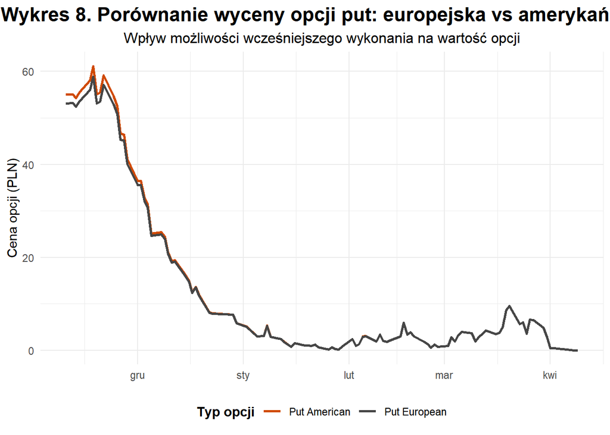

```r
df_put_plot = put_american %>%
  left_join(
    put_eur %>% select(date, bs_price),
    by = "date"
  ) %>%
  select(date, american_price, bs_price) %>%
  pivot_longer(
    cols = c(american_price, bs_price),
    names_to = "type",
    values_to = "price"
  ) %>%
  mutate(
    type = case_when(
      type == "american_price" ~ "Put American",
      type == "bs_price" ~ "Put European"
    )
  )

put_colors = c(
  "Put European" = "#464646",
  "Put American" = "#D04A02"
)

# KROK 3 wykres
ggplot(df_put_plot, aes(x = date, y = price, color = type)) +
  geom_line(linewidth = 0.9) +

  scale_color_manual(values = put_colors) +

  theme_minimal() +

  labs(
    title = "Wykres 8. Porównanie wyceny opcji put: europejska vs amerykańska",
    subtitle = "Wpływ możliwości wcześniejszego wykonania na wartość opcji",
    x = NULL,
    y = "Cena opcji (PLN)",
    color = "Typ opcji"
  ) +

  theme(
    plot.title = element_text(hjust = 0.5, face = "bold", size = 16),
    plot.subtitle = element_text(hjust = 0.5, size = 12),
    legend.position = "bottom",
    legend.title = element_text(face = "bold")
  )
```

## 8.4 Optymalny moment wykonania

Kluczowym zagadnieniem w przypadku opcji amerykańskich pozostaje wybór optymalnego momentu wykonania, szczególnie dla opcji put.

Zgodnie z mechaniką modelu nie istnieje jedna uniwersalna reguła decyzyjna – moment wykonania zależy od relacji pomiędzy wartością natychmiastowego wykonania a wartością oczekiwaną z dalszego utrzymywania opcji.

W praktyce istotnym sygnałem jest sytuacja, w której wartość wykonania przewyższa wartość oczekiwaną (continuation value). W takim przypadku wcześniejsze wykonanie staje się optymalną decyzją.

Obie te wielkości przedstawiono na wykresie poniżej:

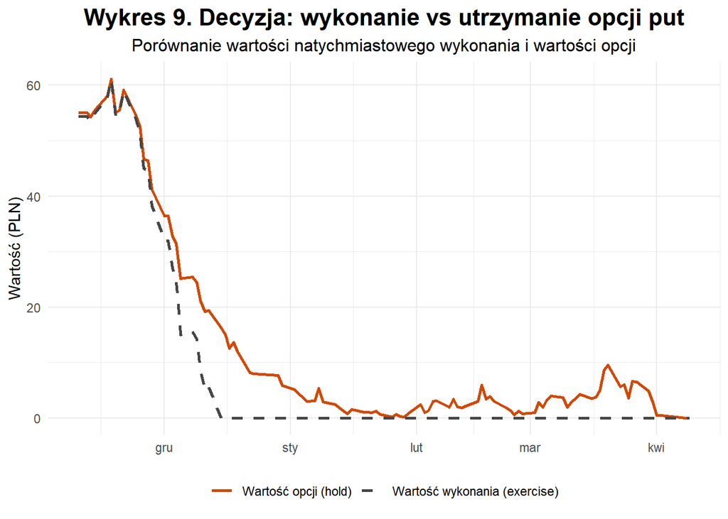

```r
df_put_exercise = put_american %>%
  left_join(
    put_eur %>% select(date, close, strike),
    by = "date"
  ) %>%
  mutate(
    exercise_value = pmax(strike - close, 0),
    diff = american_price - exercise_value,
    exercise_flag = ifelse(diff <= 0.01 & exercise_value > 0, 1, 0)
  )

ggplot(df_put_exercise, aes(x = date)) +

  geom_line(aes(y = american_price, color = "Wartość opcji (hold)"), linewidth = 0.9) +

  geom_line(aes(y = exercise_value, color = "Wartość wykonania (exercise)"),
            linewidth = 0.9, linetype = "dashed") +

  geom_point(
    data = df_put_exercise %>% filter(exercise_flag == 1),
    aes(y = exercise_value),
    color = "#d62728",
    size = 2
  ) +

  scale_color_manual(values = c(
    "Wartość opcji (hold)" = "#D04A02",
    "Wartość wykonania (exercise)" = "#464646"
  )) +

  theme_minimal() +

  labs(
    title = "Wykres 9. Decyzja: wykonanie vs utrzymanie opcji put",
    subtitle = "Porównanie wartości natychmiastowego wykonania i wartości opcji",
    x = NULL,
    y = "Wartość (PLN)",
    color = NULL
  ) +

  theme(
    plot.title = element_text(hjust = 0.5, face = "bold", size = 16),
    plot.subtitle = element_text(hjust = 0.5, size = 12),
    legend.position = "bottom"
  )
```

Analiza momentu wykonania opcji put pokazuje wyraźny rozdźwięk pomiędzy wskazaniami modelu matematycznego a praktyką rynkową:

- **Ograniczona użyteczność sygnałów krótkoterminowych:**  
  Model wskazuje pierwsze dni jako potencjalnie optymalny moment wykonania, jednak z perspektywy inwestora jest to nieefektywne – oznacza rezygnację z wartości czasowej, która stanowi istotną część ceny opcji.
- **Efekt OTM i utrata wartości ekonomicznej:**  
  Wzrost ceny KGHM szybko przesunął opcję głęboko poza pieniądz (OTM), redukując jej wartość wewnętrzną do zera. Od tego momentu wycena opiera się wyłącznie na wartości czasowej, która stopniowo wygasa.
- **Opcja jako narzędzie zabezpieczające (hedging):**  
  W praktyce opcje put pełnią funkcję ochronną. Inwestorzy utrzymują pozycję nie w celu krótkoterminowej realizacji zysku, lecz jako zabezpieczenie przed skrajnymi scenariuszami rynkowymi.

**Wniosek:**  
Modele ilościowe skutecznie identyfikują warunki teoretycznej opłacalności wykonania, jednak rzeczywiste decyzje inwestycyjne wymagają uwzględnienia wartości czasowej, strategii portfelowej oraz funkcji zabezpieczającej instrumentu.

# 9 Podsumowanie

Przeprowadzona analiza pokazuje, że wycena instrumentów pochodnych nie powinna opierać się na jednym modelu, lecz na zestawie komplementarnych podejść. Każdy z analizowanych modeli wnosi inną perspektywę na ryzyko i wycenę.

- W analizie skonstruowano opcje europejskie typu **call** oraz **put** na podstawie akcji spółki KGHM.
- Dane wejściowe oparto na skorygowanej cenie zamknięcia (adjusted close), uwzględniającej reinwestycję dywidend, co zapewnia spójność analityczną stóp zwrotu.
- Ze względu na ograniczoną dostępność danych rynkowych nie było możliwe pełne odwzorowanie krzywej OIS, dlatego zastosowano uproszczone podejście oparte na interpolacji stawek WIBOR (krótki termin) oraz rentowności obligacji skarbowych (długi termin).
- Uzyskana struktura terminowa sugeruje oczekiwania rynku dotyczące spadku stóp procentowych, co znajduje odzwierciedlenie w relatywnie niższych stopach dla średnich terminów zapadalności.
- Parametry opcji zostały określone następująco: cena wykonania (strike) 250 PLN, cena instrumentu bazowego w dniu zawarcia 196,65 PLN oraz horyzont czasowy 6 miesięcy.

**Wycena i zachowanie opcji**

- Model Blacka–Scholesa wycenił opcję call w pierwszym dniu na poziomie 2,97 PLN, co wynikało z niskiego prawdopodobieństwa osiągnięcia ceny wykonania (opcja początkowo OTM). Jednocześnie opcja put znajdowała się w stanie ITM.
- Silniejszy niż zakładany wzrost ceny akcji doprowadził do odwrócenia sytuacji – finalnie opcja call generowała istotny zysk (ok. 60 PLN na opcję), podczas gdy opcja put wygasła bez wartości.

**Porównanie metod wyceny**

- Symulacja Monte Carlo (10 tys. i 50 tys. ścieżek) dała wyniki bardzo zbliżone do modelu Blacka–Scholesa, przy czym większa liczba symulacji prowadziła do lekkiego oddalenia wyceny od wyniku analitycznego.
- Początkowa wycena opcji call wyniosła odpowiednio 2,94 PLN (10k) oraz 2,89 PLN (50k), co potwierdza wysoką spójność metod przy jednoczesnym wpływie losowości symulacji.
- Inwestycja w opcję call charakteryzowała się bardzo wysoką dźwignią finansową, co znacząco amplifikowało zarówno potencjalne zyski, jak i ryzyko.

**Opcje amerykańskie i decyzje inwestycyjne**

- Wycena opcji amerykańskich dla opcji call była praktycznie identyczna jak dla europejskich, co wynika z braku ekonomicznego uzasadnienia dla wcześniejszego wykonania (koszt alternatywny kapitału).
- Model drzewa dwumianowego (CRR) nie wskazuje jednoznacznego momentu sprzedaży, a jedynie identyfikuje warunki, w których wykonanie może być teoretycznie opłacalne.
- W praktyce decyzje inwestycyjne są silnie uzależnione od czynników behawioralnych oraz strategii portfelowej, a nie wyłącznie od wskazań modelu.

**Wniosek końcowy**

- Nawet najbardziej zaawansowane modele wyceny nie są w stanie w pełni uchwycić rzeczywistego zachowania rynku, w szczególności w kontekście nieprzewidywalnych zdarzeń oraz irracjonalnych reakcji inwestorów.

Skuteczna analiza wymaga nie tylko poprawnej implementacji modeli, ale również ich świadomej interpretacji w kontekście rynkowym i behawioralnym.